# Lab 9

Wayne Stewart

March 16, 2018

# Analysis of the Wais data set

## Discussion of the data

1. We consider the data of Agresti (1990, pp. 122-123)
2. 54 elderly people completed a subtest of the Wechsler Adult Intelligence Scale (WAIS) resulting in a discrete score with range from 0 to 20.
3. Aim: identify people with senility symptoms (binary variable) using the WAIS score.
4. Interest also lies in calculating WAIS scores that correspond to increased probability of senility symptoms (i.e., with $p >0.5$).

## Read in the data

```r
wais.df = read.csv("wais.csv")
head(wais.df)
```

```
##   wais senility
## 1    9        1
## 2   13        1
## 3    6        1
## 4    8        1
## 5   10        1
## 6    4        1
```

```r
dim(wais.df)
```

```
## [1] 54  2
```

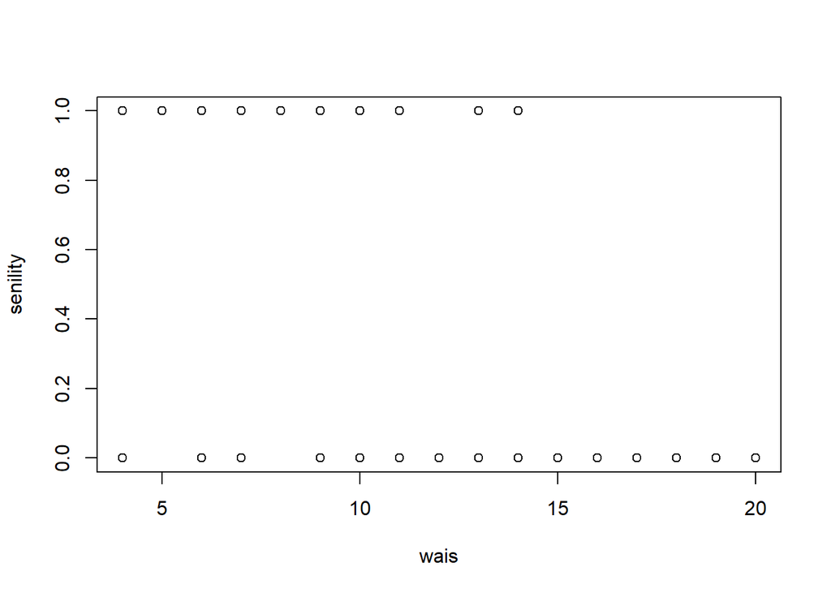

```r
plot(senility ~ wais, data = wais.df)
```

## Task 1: Complete the Jags script to analyze the data

```r
library(rjags)
#Define the model:
modelString = "
model{
for(i in 1:Ntotal)
{




y[i] ~ dbin(p[i],1)


}



}
" # close quote for modelString
writeLines( modelString , con="TEMPmodel.txt" )

# Initialize the chains based on MLE of data.
# Option: Use single initial value for all chains:
#  thetaInit = sum(y)/length(y)
#  initsList = list( theta=thetaInit )

initsList = list(beta0 = -5, beta1 = 0.01)
# Run the chains:
jagsModel = jags.model( file="TEMPmodel.txt" , data=dataList , inits=initsList ,
                        n.chains=3 , n.adapt=500 )
list.samplers(jagsModel)

update( jagsModel , n.iter=500 )
codaSamples = coda.samples( jagsModel , variable.names=c("beta0", "beta1"),
                            n.iter=33340 )
save( codaSamples , file=paste0("lab9","Mcmc.Rdata") )

summary(codaSamples)

library(ggmcmc)
s = ggs(codaSamples)
ggs_density(s)

ggs_crosscorrelation(s)
```

# Algebraic investigation of the logistic model

$$odds = \frac{p}{1-p}$$

## Task 2: Solve for $p$

$$p = odds(1-p)$$
$$p(1+odds)=odds$$
$$p=\frac{odds}{1+odds}$$

## Task 3: If $odds = 1$ then $p=\frac{1}{2}$?

## Task 4: If $odds < 1$ then $p<$?

$$p<0.5$$

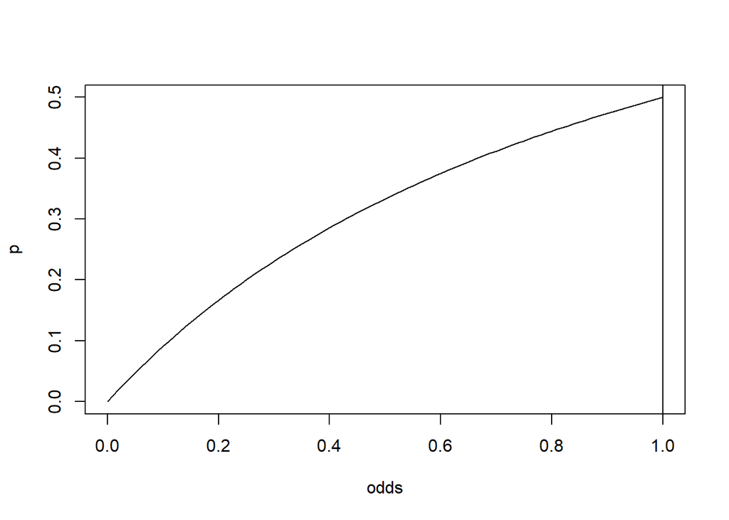

```r
curve(x/(1+x),xlim=c(0,1),xlab="odds",ylab="p")
abline(v=1)
```

# Odds and odds ratios

The probability of a success is $p=P(Y=1)$, but if we use a linear predictor to estimate $Y$ then $p$ will be a function of covariates. Suppose we have just on $x$, then
$$logit(p_i) = \beta_0 +\beta_1 x_i$$
Notice that $p_i$ is function of $x_i$, you see that by noticing the index $i$.

$$Y_i\sim Bin(p_i, n_i)$$

and using the definition of $logit$ we can write

$$log(odds_i) = \beta_0 +\beta_1 x_i$$

If we wish to compare the odds under two different $X$ values:

We define:

$$odds(X=x) = \frac{P(Y=1|X=x)}{P(Y=0|X=x)}$$

So that:

$$OR_{12}=\frac{odds(X=1)}{odds(X=2)}=a$$

## If $a=1$ then:

$$odds(X=1)=odds(X=2)$$

## If $a>1$ then:

$$odds(X=1) >odds(x=2)$$

# Logistic model and parameters as they relate to odds

$$logit(p) = log(odds(x))=\beta_0 + \beta_1 x$$
Then:

$$exp(logit(p))=exp(log(odds(x)))=exp(\beta_0+\beta_1x)=B_0B_1^x$$

$$odds(x) = B_0 B_1^x$$

$$OR_{x+1,x}=\frac{odds(x+1)}{odds(x)} =\frac{B_0B_1^{x+1}}{B_0B_1^x}=B_1=e^{\beta_1}$$
$$Percentage \; increase = \frac{final-initial}{initial}\times 100$$

$$percentage\; increase\; in\; odds\; for\; 1\; unit\; increase\; in\; x= \frac{B_0B_1^x(B_1-1)}{B_0B_1^x}\times 100=(B_1-1)\times 100$$

# Task 5: Find the expression for odds(0)

$$odds(0) = B_0B_1^0$$
$$odds(0)=B_0=exp(\beta_0)$$

# Task 6: Find the expression for $X=x(p=0.5)$

$$log(0.5/(1-0.5)=\beta_0 +\beta_1x$$
$$0=\beta_0+\beta_1x$$
$$x=-\frac{\beta_0}{\beta_1}$$

This is for the case when disease probability is 0.5.

# Task 7: Add the logical nodes necessary to track the $OR_{x+1,x}$ , $odds(0)$ and $X=x(p=0.5)$ and run the Jags script – give point and interval estimates. Interpret output.

To answer task 7 you will need to be able to interpret the meaning of these nodes.